# Income growth rates

Use income growth data `sample_growth_tb` to plot density curves and mean excess functions for annual growth rates and growth rates over each period starting in 2014.

## 1 Density estimation

```r
library(tidyverse)
library(pins)

# Specify relative paths for the board, figure output directory, and plotting theme.
board <- board_folder("../income_board_replicate")
graph_dir <- "graph"
dir.create(graph_dir, recursive = TRUE, showWarnings = FALSE)
source("theme_ipsum_like.R")
theme_set(theme_ipsum())
```

**Data loading and sample selection**

Load `sample_growth_tb` and select observations meeting the following conditions for each period.

- Beginning-of-period income `pre_income` of at least $4 \times 10^6$ yen (4 million yen)
- Beginning-of-period age $25 \leq \mathrm{age} \leq 60$

Calculate age as the beginning year extracted from period label `year` minus the birth year in the first four characters of `birth_date`.

```r
library(scattermore)

sample_growth_tb <- board |> pin_read("sample_growth_tb") |>
  mutate(age = as.numeric(str_c(20, str_sub(year,6,7))) - as.numeric(str_sub(birth_date, 1, 4))) |>
  filter(pre_income >= 4*10^6,
         age >= 25, age <= 60)

year_labels <- c(
  "g_20_19" = "2019–20",
  "g_19_18" = "2018–19",
  "g_18_17" = "2017–18",
  "g_17_16" = "2016–17",
  "g_16_15" = "2015–16",
  "g_15_14" = "2014–15",
  "g_16_14" = "2014–16",
  "g_17_14" = "2014–17",
  "g_18_14" = "2014–18",
  "g_19_14" = "2014–19",
  "g_20_14" = "2014–20"
)
```

**Annual growth distributions by period**

- Compare growth rates across the six periods from 2014–15 through 2019–20
- Estimate densities using nonzero growth observations with an absolute value below 3.5
- Output two figures, with density on a linear and a logarithmic vertical scale

For the linear-density figure, display growth from −1 to 1; for the log-density figure, display growth from −2 to 2 and density from $10^{-3}$ to $10^{1.5}$.

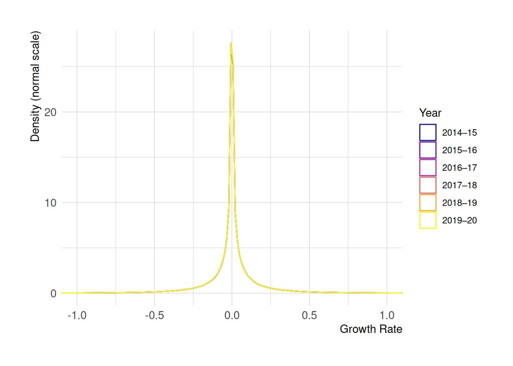

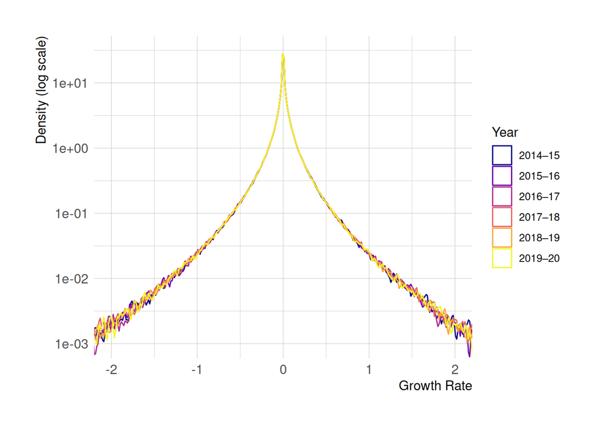

```r
growth_df_plot <- sample_growth_tb |>
  filter(year %in% c("g_20_19", "g_19_18", "g_18_17", "g_17_16", "g_16_15", "g_15_14"),
         abs(growth) < 3.5, growth != 0) |>
ggplot() +
  geom_density(aes(growth, color = year)) +
  scale_color_viridis_d(
    option = "C",
    labels = year_labels
  )

growth_df_plot +
  coord_cartesian(xlim = c(-1.0,1.0)) +
  labs(
      x = "Growth Rate",
      y = "Density (normal scale)",
      color = "Year",
  )
ggsave(filename = "growth_df_main_var_diff_year.png", path = graph_dir)
growth_df_plot +
  scale_y_log10() +
  coord_cartesian(xlim = c(-2.0,2.0), ylim = c(10^{-3.0}, 10^{1.5})) +
  labs(
      x = "Growth Rate",
      y = "Density (log scale)",
      color = "Year",
  )
ggsave(filename = "growth_df_main_var_diff_year_log.png", path = graph_dir)
```

**Growth distributions for periods starting in 2014**

- Compare the six periods starting in 2014, from 2014–15 through 2014–20
- Estimate densities using nonzero growth observations with an absolute value below 3.5
- Output two figures, with density on a linear and a logarithmic vertical scale

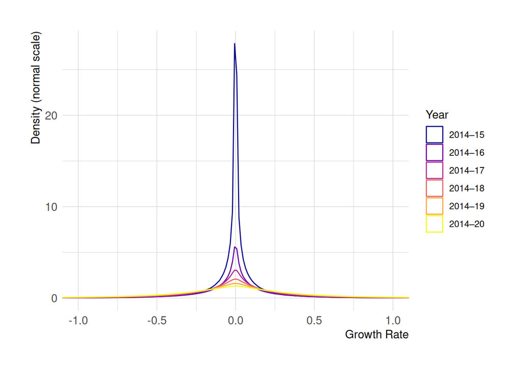

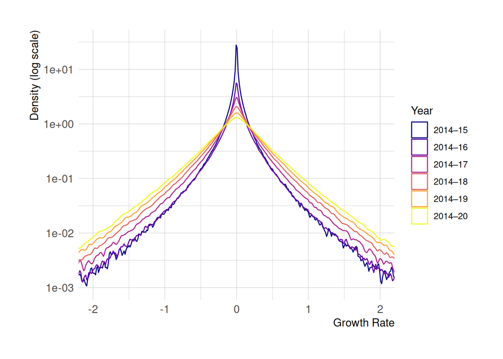

```r
growth_long_plot <- sample_growth_tb |>
  filter(str_sub(year, 6, 7) == "14",
         abs(growth) < 3.5, growth != 0) |>
ggplot() +
  geom_density(aes(growth, color = year)) +
  scale_color_viridis_d(
    option = "C",
    labels = year_labels
  )

growth_long_plot +
  coord_cartesian(xlim = c(-1.0, 1.0)) +
  labs(
      x = "Growth Rate",
      y = "Density (normal scale)",
      color = "Year",
  )
ggsave(filename = "long_term_growth_df_main_var.png", path = graph_dir)
growth_long_plot +
  scale_y_log10() +
  coord_cartesian(xlim = c(-2.0,2.0), ylim = c(10^{-3.0}, 10^{1.5})) +
  labs(
      x = "Growth Rate",
      y = "Density (log scale)",
      color = "Year",
  )
ggsave(filename = "long_term_growth_df_main_var_log.png", path = graph_dir)
```

## 2 Mean Excess Function

Sort `growth` in descending order, $g_{(1)}\geq\cdots\geq g_{(n)}$, and calculate the following expression.

$$\widehat m_j=\frac{1}{j-1}\sum_{i=1}^{j-1}g_{(i)}-g_{(j)}, \qquad j\geq2.$$

Plot the growth threshold on the horizontal axis, using colors to distinguish periods. Include growth rates outside the displayed range in the calculations.

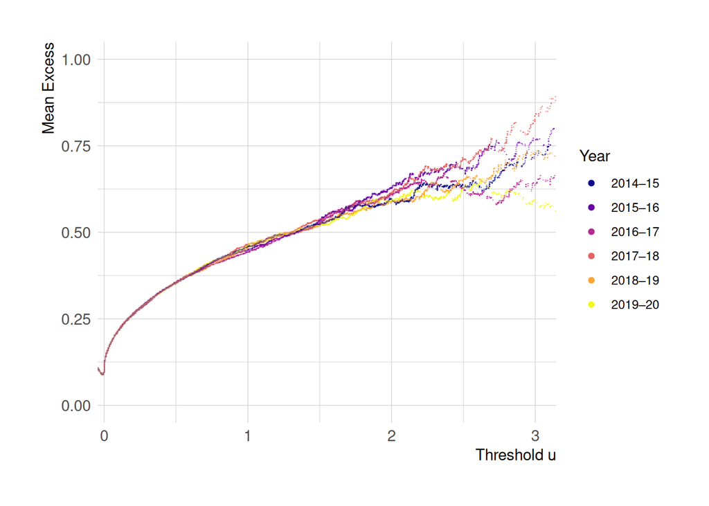

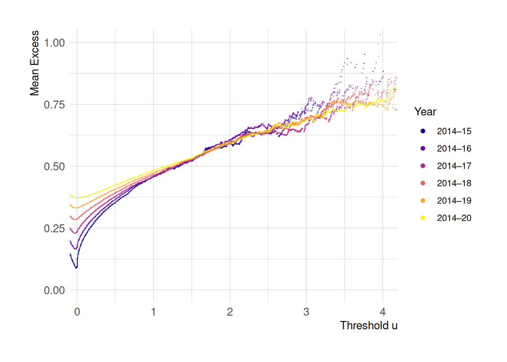

```r
mean_excess_plot_f <- \(x){
  x |>
    arrange(desc(growth)) |>
    group_by(year) |>
    mutate(m_excess = lag(cummean(growth)) - growth) |>
  ggplot(aes(growth, m_excess, color = year)) +
    geom_scattermore(pointsize = 1.2) +
    scale_color_viridis_d(
      option = "C",
      labels = year_labels
    )
}

sample_growth_tb |>
  filter(year %in% c("g_20_19", "g_19_18", "g_18_17", "g_17_16", "g_16_15", "g_15_14")) |>
  mean_excess_plot_f() +
  coord_cartesian(xlim = c(0.1, 3.0), ylim = c(0, 1.0)) +
  labs(
      x = "Threshold u",
      y = "Mean Excess",
      color = "Year",
  )
ggsave(filename = "mean_excess_main_var_diff_year.png", path = graph_dir)

sample_growth_tb |>
  filter(str_sub(year, 6, 7) == "14") |>
  mean_excess_plot_f() +
  coord_cartesian(xlim = c(0.1, 4.0), ylim = c(0, 1.0)) +
  labs(
      x = "Threshold u",
      y = "Mean Excess",
      color = "Year",
  )
ggsave(filename = "mean_excess_main_var_long_growth.png", path = graph_dir)
```